# Problem Set 1

Due date: Monday, 15 September

Please upload your completed assignment to the ELMs course site (under the assignments menu) and to your class Github repository. You need to upload both your Quarto document (with R code, as needed) and its rendered output (either as a PDF or HTML file).

**Total points: 25**

**Note**

To complete this problem set, you will need access to the `polisciols` R package. This package is not published on CRAN[^1], so you will need to install it using the following code:

```r
install.packages("devtools")

devtools::install_github("hgoers/polisciols")
```

Remember, you only need to do this once on your computer. Run this in the console. Do not include it in your Quarto document.

The [American National Election Studies](https://electionstudies.org/) surveys a representative sample of US voters prior to and following each US Presidential Election. We will use their survey from the last US Presidential Election (held in 2024) to learn more about US voters.

**Tip**

The `nes2024` data set in the `polsciols` R package provides you with a selection of the hundreds of questions the ANES asked of all 5,521 respondents to the 2024 survey. Each row provides data for one respondent.

**For this problem set, only include observations for which full responses were recorded (exclude those who, for any question included in the dataset, refused to answer it, didn’t know the answer, or have missing responses).**

## Question 1

Prior to the 2024 US Presidential Election, the ANES asked respondents their highest level of school completed or highest degree received.

```r
library(tidyverse)
library(skimr)
library(janitor)
library(devtools)
library(polisciols)
```

### Part A

*Points: 2*

What was the most common highest level of education obtained by respondents? What was the least common? *Use the `education` variable from the `nes2024` data set to answer these questions.*

```r
tabyl(nes2024, education)
```

```
                                   education    n      percent
                                     Refused   26 0.0047092918
                                  Don't know    1 0.0001811266
                                        <NA>   29 0.0052526716
            Less than high school credential  283 0.0512588299
                      High school credential  973 0.1762361891
 Some post-high school, no bachelor’s degree 1738 0.3147980438
                           Bachelor’s degree 1384 0.2506792248
                             Graduate degree 1087 0.1968846224
```

The most common level of education was “some post-high school, no bachelor’s degree.” The least common level of education was “less than high school credential.”

### Part B

*Points: 2*

Describe the distribution of the total number of respondents that obtained each highest level of education. Include a plot of those counts.

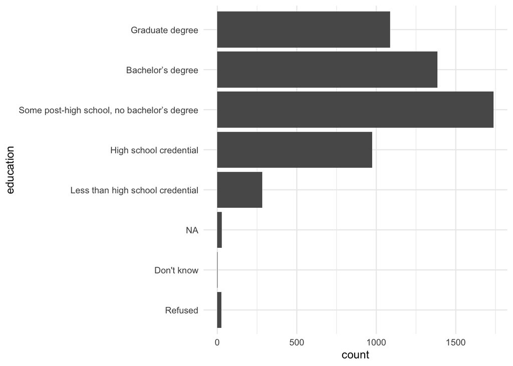

```r
ggplot(nes2024, aes(y=education))+
  geom_bar()+
  theme_minimal()
```

Based on the plot above, the most common highest highest level of education was some post high school, no bachelor’s degree.

## Question 2

The ANES also asked each respondent how often they pay attention to what is going on in government and politics. Let’s use these responses to learn more about how much attention US voters pay to politics ahead of a Presidential election.

### Part A

*Points: 2*

How often did individuals pay attention to what was going on in government and politics? What was the most popular level of attention? What was the least? *Use the `attention_to_politics` variable from the `nes2024` data set to answer these questions.*

```r
tabyl(nes2024, attention_to_politics)
```

```
 attention_to_politics    n      percent
                 Never  101 0.0182937874
      Some of the time 1109 0.2008694077
   About half the time 1111 0.2012316609
      Most of the time 2055 0.3722151784
                Always 1143 0.2070277124
                  <NA>    1 0.0001811266
               Refused    1 0.0001811266
```

*Points: 3*

Describe the distribution of the total number of respondents who provided each answer to this question. Does this distribution indicate that individuals tend to pay very little, a moderate, or a lot of attention to politics prior to a US Presidential Election? Include a plot of these counts in your answer.

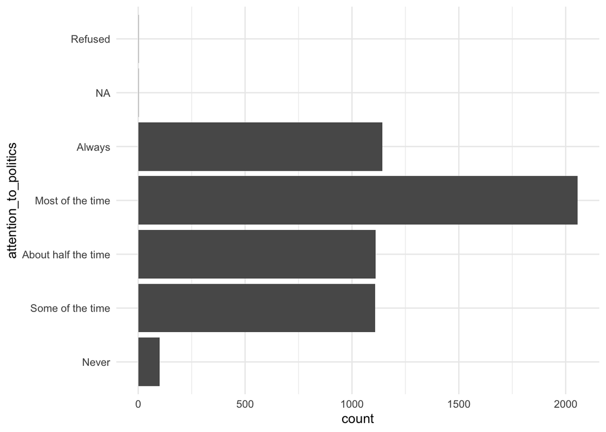

```r
ggplot(nes2024, aes(y=attention_to_politics))+
  geom_bar()+
  theme_minimal()
```

The most chosen answer was “most of the time.” This would indicate that individuals pay a lot of attention to politics prior to a Presidential election.

## Question 3

Examine the following vector of (fake) student IQ test scores:

```r
iq <- c(
  145, 139, 126, 122, 125, 130, 96, 110, 118, 118, 101, 142, 134, 124, 112, 109,
  134, 113, 81, 113, 123, 94, 100, 136, 109, 131, 117, 110, 127, 124, 106, 124,
  115, 133, 116, 102, 127, 117, 109, 137, 117, 90, 103, 114, 139, 101, 122, 105,
  97, 89, 102, 108, 110, 128, 114, 112, 114, 102, 82, 101
)
```

### Part A

*Points: 3*

Find the five-number summary, mean, and standard deviation for these data. Do you think any of these students might be outliers in this distribution? If so, what IQ test score did they get and how do you know?

```r
summary(iq)
```

```
   Min. 1st Qu.  Median    Mean 3rd Qu.    Max.
   81.0   104.5   114.0   115.0   125.2   145.0
```

```r
skim(iq)
```

Data summary

| Name | iq |
| --- | --- |
| Number of rows | 60 |
| Number of columns | 1 |
| _______________________ |  |
| Column type frequency: |  |
| numeric | 1 |
| ________________________ |  |
| Group variables | None |

**Variable type: numeric**

| skim_variable | n_missing | complete_rate | mean | sd | p0 | p25 | p50 | p75 | p100 | hist |
| --- | --- | --- | --- | --- | --- | --- | --- | --- | --- | --- |
| data | 0 | 1 | 114.98 | 14.8 | 81 | 104.5 | 114 | 125.25 | 145 | ▂▅▇▅▃ |

The mean is 114.9833333. The standard deviation is 14.8. The min was 81. Q1 is 104.5. Median is 114.0 Q3 is 125.2. The max was 145.0.

There is no outliers.

### Part B

*Points: 3*

In large populations, IQ test scores are standardized to have a mean of 100 and a standard deviation of 15. In what way does the distribution among these students differ from the overall population? Do not use the words and phrases “mean” or “standard deviation” in your answer.

This group of students tended to have a higher IQ when compared to the greater population.

## Question 4

*Points: 4*

The ANES collects information about each respondent’s demographics, including their race, age, household income, and party affiliation. Provide the “type” (categorical or continuous) of variable each of those demographic characteristics represents.

## Question 5

The ANES also asked respondents prior to the election to rate Kamala Harris and Donald Trump on a scale from 0 to 100.

### Part A

*Points: 3*

Plot all respondents’ answers to these two questions on a single density plot. There are several peaks in these distributions. What do these peaks have in common? What might they suggest about how people answer questions that ask them to provide a single number along a large range?

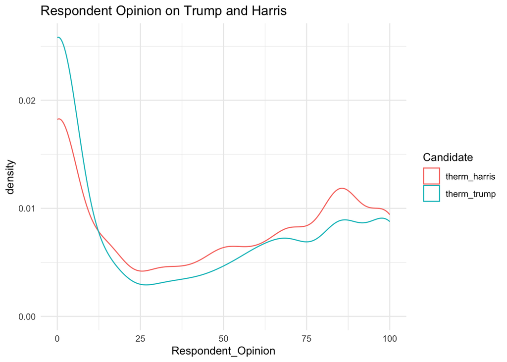

```r
TrumpHarris <- pivot_longer(
  data= nes2024,
  cols = c('therm_harris', 'therm_trump'),
  names_to = "Candidate",
  values_to = "Respondent_Opinion")|>
  group_by(Candidate)|>
  ggplot()+
  geom_density(aes(x= Respondent_Opinion, colour = Candidate)) + labs (
    title= "Respondent Opinion on Trump and Harris")+
  theme_minimal()

TrumpHarris
```

### Part B

*Points: 3*

President Trump won this election. Would you predict this outcome from the way this representative sample responded to these questions? Provide a brief description of the reasoning behind your answer.

With the given information, it would be difficult to reach a prediction regarding the outcome of the election. Based on the sample and data, there is no definitive correlation betweeen a candidate’s popularity and their chances of winning.

## Footnotes

[^1]: The [Comprehensive R Archive Network (CRAN)](https://cran.r-project.org/) hosts many R packages that can be installed easily using the familiar `install.packages()` function. These packages have gone through a comprehensive quality assurance process. I wrote `polisciols` for this class and will update it regularly. I, therefore, will not host it through CRAN: the quality assurance process takes too long to be practical for our weekly schedule. Instead, you are downloading it directly from its Github repository.